# CrimeReport-Vancouver

Sanju Shree Suresh Kumar

# Motivation

Crime data analysis plays a crucial role in understanding and addressing public safety concerns within a city. By analyzing crime data, law enforcement agencies, policymakers, and researchers can gain insights into patterns, trends, and hotspots of criminal activity. This series of vignettes aims to provide a comprehensive overview of crime data analysis using R, offering techniques to uncover meaningful information from raw crime datasets. Through a step-by-step approach, we explore various aspects of crime analysis, from temporal trends and neighborhood-specific analyses to hourly patterns of criminal incidents. By highlighting the significance of such analyses, we empower stakeholders with actionable insights to devise effective strategies for crime prevention, resource allocation, and improved public safety. As we delve into each analysis, we will uncover valuable insights that contribute to safer and more secure communities.

## Introduction

This vignette introduces the usage of the CrimeReport package to analyze crime data in Vancouver. The code in this vignette demonstrates how to load the crime dataset and perform basic data exploration.

```r
library(CrimeReport)
```

## Loading Vancouver Crime Data

The following code snippet defines a function load_vancouver_crime_data() which reads the crime dataset from the package’s extdata directory. This dataset contains information about crime incidents in Vancouver.

```r
load_vancouver_crime_data <- function() {
  # Use system.file to locate the CSV file
  data_path <- system.file("extdata", "crime.csv", package = "CrimeReport")
  crime_data <- readr::read_csv(data_path)
  return(crime_data)
}
```

### Exploring the Crime Dataset

In this section, we load the crime dataset using the load_vancouver_crime_data() function and perform some basic data exploration.

```r
crime_data <- load_vancouver_crime_data()
```

Display the first few rows of the crime dataset to get an overview of the available columns and data entries.

```r
print(head(crime_data))
```

```
#> # A tibble: 6 × 12
#>   TYPE   YEAR MONTH   DAY  HOUR MINUTE HUNDRED_BLOCK NEIGHBOURHOOD      X      Y
#>   <chr> <dbl> <dbl> <dbl> <dbl>  <dbl> <chr>         <chr>          <dbl>  <dbl>
#> 1 Othe…  2003     5    12    16     15 9XX TERMINAL… Strathcona    4.94e5 5.46e6
#> 2 Othe…  2003     5     7    15     20 9XX TERMINAL… Strathcona    4.94e5 5.46e6
#> 3 Othe…  2003     4    23    16     40 9XX TERMINAL… Strathcona    4.94e5 5.46e6
#> 4 Othe…  2003     4    20    11     15 9XX TERMINAL… Strathcona    4.94e5 5.46e6
#> 5 Othe…  2003     4    12    17     45 9XX TERMINAL… Strathcona    4.94e5 5.46e6
#> 6 Othe…  2003     3    26    20     45 9XX TERMINAL… Strathcona    4.94e5 5.46e6
#> # ℹ 2 more variables: Latitude <dbl>, Longitude <dbl>
```

Calculate the number of rows and columns in the dataset and print the results.

```r
num_rows <- nrow(crime_data)
num_cols <- ncol(crime_data)
cat("Number of rows:", num_rows, "\n")
```

```
#> Number of rows: 530652
```

```r
cat("Number of columns:", num_cols, "\n")
```

```
#> Number of columns: 12
```

This section of the vignette illustrates the process of loading the Vancouver crime dataset using the load_vancouver_crime_data() function and conducting basic data exploration tasks.

# Analyzing Temporal Trends in Crime Incidents

This vignette demonstrates the process of analyzing temporal trends in crime incidents using the analyze_temporal_trends function from the CrimeReport package. The code provided below utilizes data manipulation, visualization, and summary statistics to uncover insights about crime trends over different years and months.

## Analyzing Yearly Trends

In this section, we examine the yearly trends in crime incidents. The analyze_temporal_trends function aggregates crime data by year and creates a bar plot displaying the distribution of incidents for each year.

```r
library(dplyr)
```

```r
library(ggplot2)
analyze_temporal_trends <- function(crime_data) {
    # Yearly trends
    year_counts <- crime_data %>%
        group_by(YEAR) %>%
        summarize(count = n())

    year_plot <- ggplot(year_counts, aes(x = YEAR, y = count, fill = factor(YEAR))) +
        geom_bar(stat = "identity", color = "black", alpha = 0.7) +
        labs(x = "Year", y = "Number of Incidents", title = "Yearly Trends in Crime Incidents") +
        scale_x_continuous(breaks = year_counts$YEAR, labels = year_counts$YEAR, expand = c(0, 0)) +
        theme_minimal() +
        theme(legend.position = "none")  # Remove the legend

    # Calculate summary statistics for years
    min_crimes <- min(year_counts$count)
    max_crimes <- max(year_counts$count)
    median_crimes <- median(year_counts$count)

    # Create text results for the yearly trend
    text_results <- paste(
        "Summary Statistics for Yearly Trend:",
        "Minimum number of crimes in a year:",
        paste("  - Year:", year_counts$YEAR[which(year_counts$count == min_crimes)], "Count:", min_crimes),
        "Maximum number of crimes in a year:",
        paste("  - Year:", year_counts$YEAR[which(year_counts$count == max_crimes)], "Count:", max_crimes),
        "Median number of crimes in a year:",
        paste("  - Year:", year_counts$YEAR[which(year_counts$count == median_crimes)], "Count:", median_crimes)
    )

    # Monthly trends for specific years (2003, 2015, 2017)
    specific_years <- c(2003, 2015, 2017)
    specific_year_month_results <- lapply(specific_years, function(year) {
        year_month_counts <- crime_data %>%
            filter(YEAR == year) %>%
            group_by(MONTH) %>%
            summarize(count = n())

        month_plot <- ggplot(year_month_counts, aes(x = MONTH, y = count)) +
            geom_line(color = "blue") +
            labs(x = "Month", y = "Number of Incidents", title = paste("Monthly Trends in Crime Incidents for Year", year)) +
            scale_x_continuous(breaks = 1:12, labels = month.abb, expand = c(0, 0)) +
            theme_minimal() +
            theme(legend.position = "none")

        # Calculate summary statistics for specific year and month
        min_month_crimes <- min(year_month_counts$count)
        max_month_crimes <- max(year_month_counts$count)
        median_month_crimes <- median(year_month_counts$count)

        # Create text results for specific year and month
        month_text_results <- paste(
            "Summary Statistics for Monthly Trend in Year", year,
            "Minimum number of crimes in a month:",
            paste("  - Month:", month.abb[which(year_month_counts$count == min_month_crimes)], "Count:", min_month_crimes),
            "Maximum number of crimes in a month:",
            paste("  - Month:", month.abb[which(year_month_counts$count == max_month_crimes)], "Count:", max_month_crimes),
            "Median number of crimes in a month:",
            paste("  - Month:", month.abb[which(year_month_counts$count == median_month_crimes)], "Count:", median_month_crimes)
        )

        list(
            year = year,
            month_plot = month_plot,
            month_text_results = month_text_results
        )
    })

    list(
        year_plot = year_plot,
        text_results = text_results,
        specific_year_month_results = specific_year_month_results
    )
}
```

## Analyzing Monthly Trends

Next, we focus on analyzing the monthly trends in crime incidents for specific years (2003, 2015, and 2017). The function generates line plots illustrating the monthly distribution of incidents for each selected year.

### Visualizing Yearly Trends

The code snippet below generates a bar plot illustrating the yearly trends in crime incidents. Each bar represents a year, and the height of the bar corresponds to the number of incidents. The plot is customized with minimal styling and legend removal for clarity.

### Visualizing Monthly Trends

The code snippet below generates line plots illustrating the monthly trends in crime incidents for the specific years (2003, 2015, and 2017). Each line represents a year, and the x-axis represents the months. The plot is customized with blue lines for clarity.

```r
# Analyze temporal trends
temporal_trends <- analyze_temporal_trends(crime_data)

# Print text results for the yearly trend plot
cat(temporal_trends$text_results, "\n")
```

```
#> Summary Statistics for Yearly Trend: Minimum number of crimes in a year:   - Year: 2017 Count: 17857 Maximum number of crimes in a year:   - Year: 2003 Count: 49928 Median number of crimes in a year:   - Year: 2015 Count: 34328
```

```r
# Print the yearly trend plot
print("Yearly Trend Plot:")
```

```
#> [1] "Yearly Trend Plot:"
```

```r
print("This plot displays the trend of crime incidents over the years.")
```

```
#> [1] "This plot displays the trend of crime incidents over the years."
```

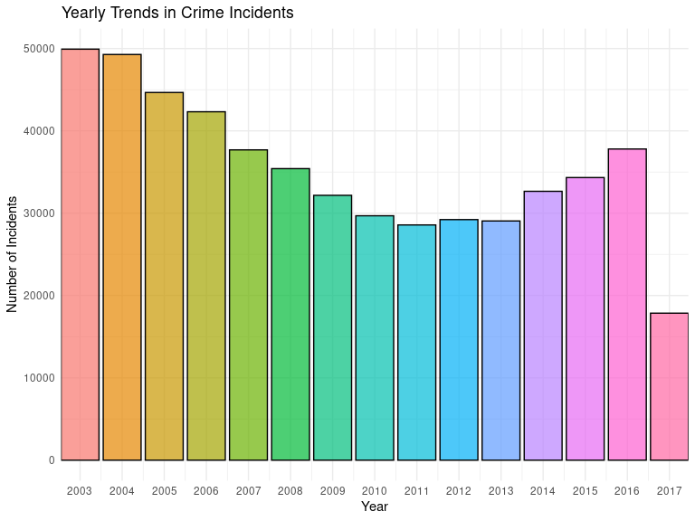

```r
print(temporal_trends$year_plot)
```

```
#> Summary Statistics for Monthly Trend in Year 2003 Minimum number of crimes in a month:   - Month: Feb Count: 3548 Maximum number of crimes in a month:   - Month: May Count: 4647 Median number of crimes in a month:   - Month:  Count: 4156.5
```

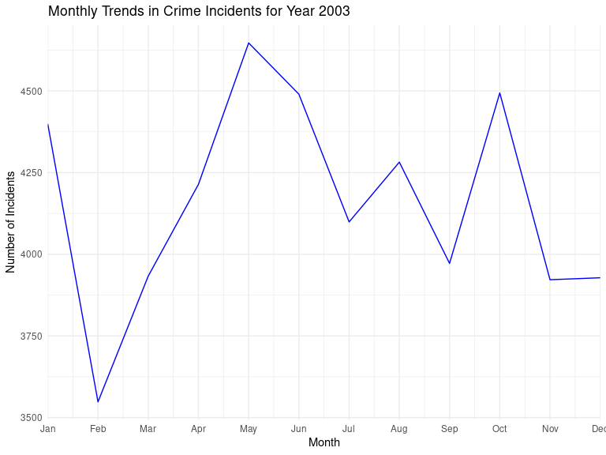

```
#> Summary Statistics for Monthly Trend in Year 2015 Minimum number of crimes in a month:   - Month: Feb Count: 2328 Maximum number of crimes in a month:   - Month: Nov Count: 3268 Median number of crimes in a month:   - Month:  Count: 2867.5
```

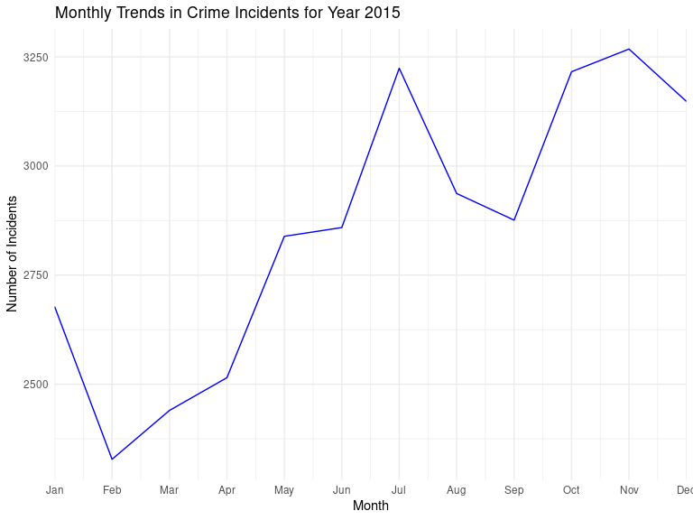

```
#> Summary Statistics for Monthly Trend in Year 2017 Minimum number of crimes in a month:   - Month: Jul Count: 1249 Maximum number of crimes in a month:   - Month: May Count: 3007 Median number of crimes in a month:   - Month: Apr Count: 2861
```

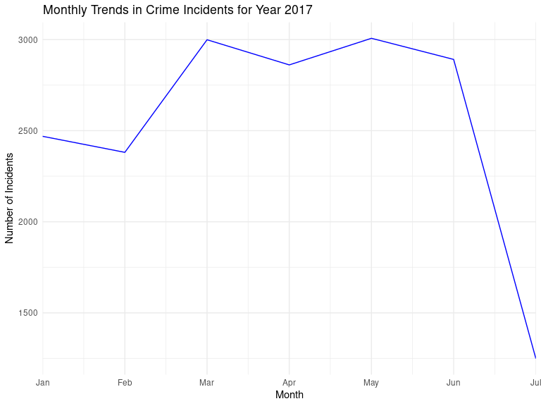

```r
# Print text results and plots for specific year and month trends
for (i in seq_along(temporal_trends$specific_year_month_results)) {
    cat(temporal_trends$specific_year_month_results[[i]]$month_text_results, "\n")
    print(temporal_trends$specific_year_month_results[[i]]$month_plot)
}
```

## Results Yearly Trends

- **2017** had the least crime incidents with **17857** cases.
- **2003** observed the highest crime incidents with **49928** cases.
- The median occurred in **2015** with **34328** cases.

For month results code will show you the overall summary for the Monthly Trends.

# Finding Highest Theft Type by Year and Month

This code presents the `find_highest_theft_type` function, which is designed to identify the most prevalent theft type for specific years and maximum months within a given dataset.

## Function Overview

The `find_highest_theft_type` function takes three main parameters: `theft_data`, a dataset containing theft information; `years`, a numeric vector indicating the years to analyze; and `max_months`, a character vector specifying the maximum months of each year to consider. The function iterates over the provided years and months, filters the dataset based on the criteria, and determines the theft type with the highest occurrence count.

```r
find_highest_theft_type <- function(theft_data, years, max_months) {
  results <- list()

  for (i in seq_along(years)) {
    year <- years[i]
    month <- max_months[i]

    # Filter data for the specified year and month
    filtered_data <- theft_data %>%
      dplyr::filter(YEAR == year, MONTH == match(month, month.abb))

    # Find the theft type with the highest count
    highest_theft_type <- filtered_data %>%
      dplyr::group_by(TYPE) %>%
      dplyr::summarize(count = n()) %>%
      dplyr::arrange(desc(count)) %>%
      dplyr::slice(1)

    results[[paste(year, month, sep = "_")]] <- highest_theft_type
  }

  return(results)
}
```

### Print the results

```r
theft_data <- load_vancouver_crime_data()
years <- c(2003, 2015, 2017)
max_months <- c("May", "Nov", "May")

highest_theft_types <- find_highest_theft_type(theft_data, years, max_months)


# Print the highest theft types for each year and month
for (key in names(highest_theft_types)) {
  year_month <- key
  highest_type <- highest_theft_types[[key]]$TYPE
  count <- highest_theft_types[[key]]$count

  cat("Year and Month:", year_month, "\n")
  cat("Highest Theft Type:", highest_type, "\n")
  cat("Count:", count, "\n\n")
}
```

```
#> Year and Month: 2003_May
#> Highest Theft Type: Theft from Vehicle
#> Count: 1873
#>
#> Year and Month: 2015_Nov
#> Highest Theft Type: Theft from Vehicle
#> Count: 1215
#>
#> Year and Month: 2017_May
#> Highest Theft Type: Theft from Vehicle
#> Count: 980
```

The analysis reveals that “Theft from Vehicle” was the most frequent theft type during specific periods:

In May 2003, there were 1873 incidents. In November 2015, there were 1215 incidents. In May 2017, there were 980 incidents. The consistent prevalence of “Theft from Vehicle” indicates a recurring pattern of this type of theft during those months.

# Finding Least Theft Type by Year and Month

The function find_least_theft_type identifies the least frequent theft type during specific periods. It analyzes the crime data to pinpoint the theft type with the lowest occurrence.

```r
find_least_theft_type <- function(theft_data, years, max_months) {
  results <- list()

  for (i in seq_along(years)) {
    year <- years[i]
    month <- max_months[i]

    # Filter data for the specified year and month
    filtered_data <- theft_data %>%
      dplyr::filter(YEAR == year, MONTH == match(month, month.abb))

    # Find the theft type with the least count
    least_theft_type <- filtered_data %>%
      dplyr::group_by(TYPE) %>%
      dplyr::summarize(count = n()) %>%
      dplyr::arrange(count) %>%
      dplyr::slice(1)

    results[[paste(year, month, sep = "_")]] <- least_theft_type
  }

  return(results)
}
```

By running the function with specified years and months, the analysis uncovers the type of theft that was least common during those periods. The results highlight the crime type with its corresponding count, offering valuable insights into crime trends.

### Print the results

```r
years <- c(2003, 2015, 2017)
max_months <- c("May", "Nov", "May")

least_theft_types <- find_least_theft_type(theft_data, years, max_months)

# Print the least theft types for each year and month
for (key in names(least_theft_types)) {
  year_month <- key
  least_type <- least_theft_types[[key]]$TYPE
  count <- least_theft_types[[key]]$count

  cat("Year and Month:", year_month, "\n")
  cat("Least Theft Type:", least_type, "\n")
  cat("Count:", count, "\n\n")
}
```

```
#> Year and Month: 2003_May
#> Least Theft Type: Homicide
#> Count: 2
#>
#> Year and Month: 2015_Nov
#> Least Theft Type: Homicide
#> Count: 1
#>
#> Year and Month: 2017_May
#> Least Theft Type: Homicide
#> Count: 1
```

The analysis reveals that “Homicide” was the least frequent theft type in the specified years and months, with counts ranging from 1 to 2 incidents.

# Neighborhood Analysis

This vignette demonstrates an analysis of neighborhood crime data using the neighborhood_analysis function from the CrimeReport package. The function identifies neighborhoods with the highest total crime incidents and provides a summary of their crime rates.

The neighborhood_analysis function allows you to perform an analysis of crime incidents by neighborhood.

```r
neighborhood_analysis <- function(crime_data, top_n = 5) {
  # Load the required package
  library(dplyr)

  neighborhood_summary <- crime_data %>%
    group_by(NEIGHBOURHOOD) %>%
    summarize(total_crimes = n()) %>%
    arrange(desc(total_crimes))

  top_neighborhoods <- head(neighborhood_summary, n = top_n)

  return(list(
    neighborhood_summary = neighborhood_summary,
    top_neighborhoods = top_neighborhoods
  ))
}
```

## Top 5 Neighborhoods with High Crime Rates and Summary

The neighborhood crime analysis provides insights into the distribution of crime incidents across neighborhoods, helping to identify areas with high crime rates. This information can be valuable for crime prevention and law enforcement strategies.

```r
# Perform neighborhood analysis
neighborhood_analysis_result <- neighborhood_analysis(crime_data, top_n = 5)

# View the neighborhood summary
print("Neighborhood Summary:")
```

```
#> [1] "Neighborhood Summary:"
```

```r
print(neighborhood_analysis_result$neighborhood_summary)
```

```
#> # A tibble: 25 × 2
#>    NEIGHBOURHOOD             total_crimes
#>    <chr>                            <int>
#>  1 Central Business District       110947
#>  2 <NA>                             56624
#>  3 West End                         41352
#>  4 Fairview                         32161
#>  5 Mount Pleasant                   30536
#>  6 Grandview-Woodland               27180
#>  7 Renfrew-Collingwood              26761
#>  8 Kitsilano                        26699
#>  9 Kensington-Cedar Cottage         24941
#> 10 Strathcona                       20919
#> # ℹ 15 more rows
```

```r
# View the top neighborhoods with high crime rates
print("Top Neighborhoods with High Crime Rates:")
```

```
#> [1] "Top Neighborhoods with High Crime Rates:"
```

```r
print(neighborhood_analysis_result$top_neighborhoods)
```

```
#> # A tibble: 5 × 2
#>   NEIGHBOURHOOD             total_crimes
#>   <chr>                            <int>
#> 1 Central Business District       110947
#> 2 <NA>                             56624
#> 3 West End                         41352
#> 4 Fairview                         32161
#> 5 Mount Pleasant                   30536
```

The analysis showcases the neighborhood summary of total crime incidents and highlights the top 5 neighborhoods with the highest crime rates.

# Crime Count By Crime Type

The following code snippet presents a function for calculating the total crime count by type in a specific neighborhood, year, and month. It then generates a set of bar plots, each depicting the total crime count by type in the specified neighborhood for different combinations of years and months. The plots are displayed individually.

```r
calculate_total_crime_count_by_type_neighborhood <- function(crime_data, neighborhood, year, month) {
  crime_count <- crime_data %>%
    filter(NEIGHBOURHOOD == neighborhood, YEAR == year, MONTH == month) %>%
    group_by(TYPE) %>%
    summarize(count = n())

  return(crime_count)
}
```

### Visualizing the plots

This code calculates and visualizes the total crime count by type in the specified neighborhood for different combinations of years and months using bar plots. The plots are presented individually, showcasing the variation in crime types across different time periods.

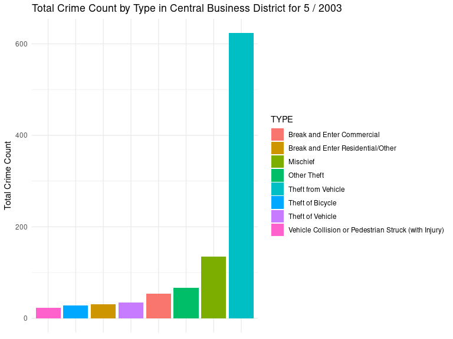

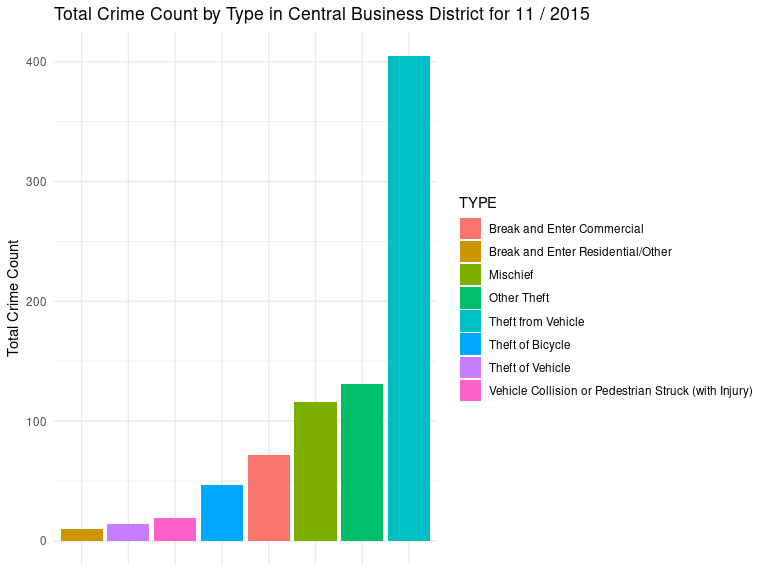

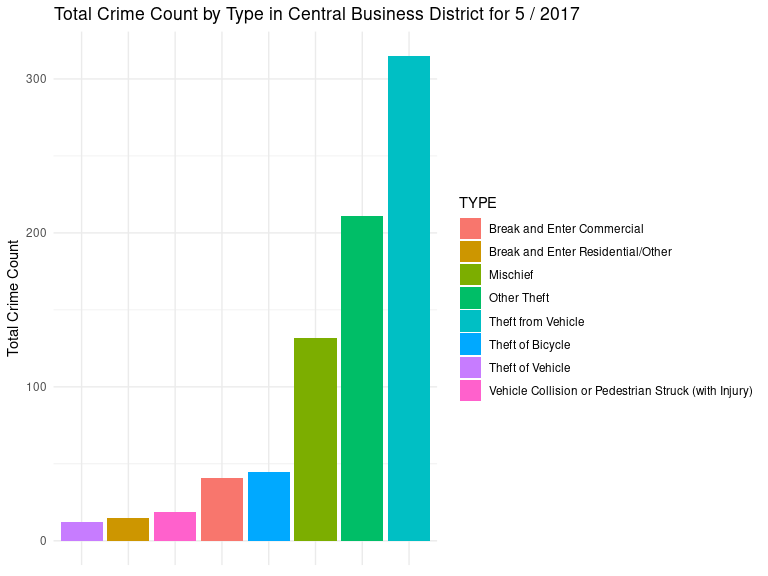

```r
# Load required packages
library(ggplot2)

# Specify the neighborhood and months
neighborhood <- "Central Business District"
years <- c(2003, 2015, 2017)
months <- c(5, 11, 5)

# Create a list to store plots
plots <- list()

# Loop through each combination of year and month
for (i in seq_along(years)) {
  year <- years[i]
  month <- months[i]

  # Calculate total crime count by type in the specified neighborhood, year, and month
  crime_count_by_type <- calculate_total_crime_count_by_type_neighborhood(crime_data,
                                                                           neighborhood,
                                                                           year,
                                                                           month)

  # Create a bar plot using ggplot2 for the current year and month
  plot <- ggplot(crime_count_by_type, aes(x = reorder(TYPE, count), y = count, fill = TYPE)) +
    geom_bar(stat = "identity") +
    labs(x = NULL, y = "Total Crime Count",
         title = paste("Total Crime Count by Type in", neighborhood, "for", month, "/", year)) +
    theme_minimal() +
    theme(axis.text.x = element_blank(), axis.ticks.x = element_blank())

  plots[[paste(year, month, sep = "_")]] <- plot
}

# Display the plots
for (plot in plots) {
  print(plot)
}
```

From the Neighbourhood Analysis we found that high crime happened in the Central Business District so plotted for same.

# Analyzing Crime Incidents by Hour and Type

This vignette demonstrates an analysis of crime incidents by hour and type. The code includes a function calculate_crime_count_by_hour_type that calculates crime counts by hour and type for specified years and months. It also provides visualizations in the form of heatmaps, displaying the distribution of crime incidents based on hour and type for different year and month combinations.

## Functions

This function calculates crime counts by hour and type using the provided crime data. It takes input parameters for years and months to filter the data, and returns a summary of crime counts by hour and type.

```r
calculate_crime_count_by_hour_type <- function(crime_data, years, months) {
  crime_count <- crime_data %>%
    filter(YEAR %in% years, MONTH %in% months) %>%
    group_by(HOUR, TYPE) %>%
    summarize(count = n())

  return(crime_count)
}
```

### Heatmap Visualizations

The code also includes visualizations in the form of heatmaps. For each specified year and month combination, a heatmap is created using the ggplot2 package. Each cell in the heatmap represents the count of crime incidents for a specific hour and crime type.

```
#> Warning: Removed 2 rows containing missing values (`geom_tile()`).
```

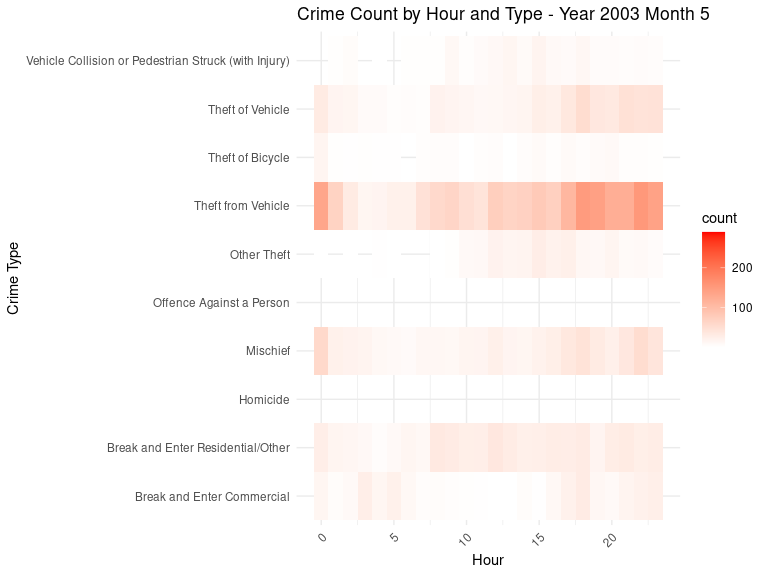

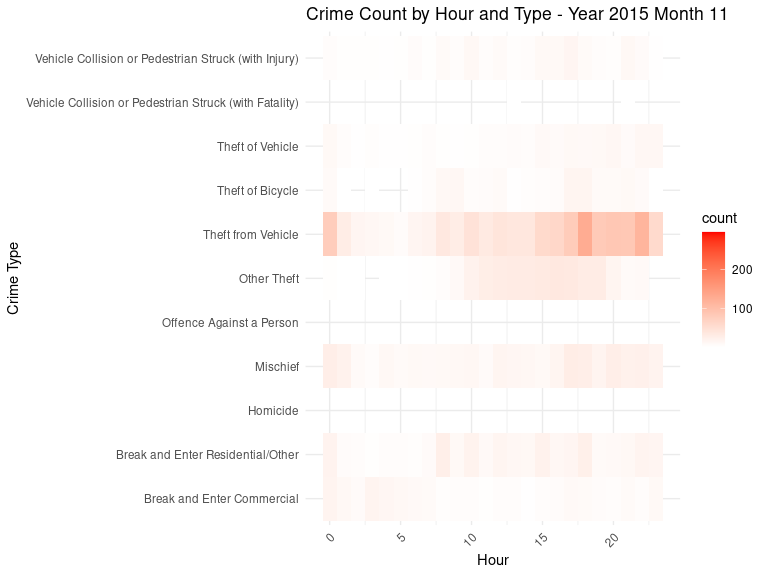

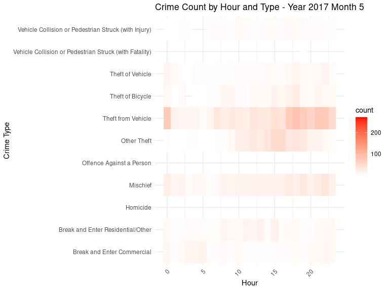

```r
# Load required packages
library(dplyr)
library(ggplot2)


# Specify the years and months
years <- c(2003, 2015, 2017)
months <- c(5, 11, 5)

# Create and display separate heatmaps for each year and month combination
for (i in seq_along(years)) {
  year <- years[i]
  month <- months[i]

  # Calculate crime count by hour and type for specific year and month
  crime_count_by_hour_type <- calculate_crime_count_by_hour_type(crime_data, year, month)

  # Create a heatmap using ggplot2
  heatmap_plot <- ggplot(crime_count_by_hour_type, aes(x = HOUR, y = TYPE, fill = count)) +
    geom_tile() +
    scale_fill_gradient(low = "white", high = "red") +
    labs(x = "Hour", y = "Crime Type", title = paste("Crime Count by Hour and Type - Year", year, "Month", month)) +
    theme_minimal() +
    theme(axis.text.x = element_text(angle = 45, hjust = 1))

  # Display the heatmap
  print(heatmap_plot)
}
```

The heatmaps provide a visual representation of the distribution of crime incidents based on hour and type for different time periods, enabling insights into temporal patterns of crime.